# Google Data Analytics Capstone project

James Broughman

2024-06-16

# INTRODUCTION

This is a case study of the (fictional) Cyclistic bike-share company using publicly available date from the Divvy bike share program in Chicago. The data analyzed runs from May 2023 to April 2024 and is comprised of 5,738,612 individual data points. After cleaning the data 4,500,704 data points remained and the analysis was based on this data.

The goal of this scenario is to design marketing strategies aimed at converting casual riders into annual members by better understanding how annual members and casual riders differ, why casual riders would buy a membership, and how digital media could affect their marketing tactics.

Three questions will guide the future marketing program: 1. How do annual members and casual riders use Cyclistic bikes differently? 2. Why would casual riders buy Cyclistic annual memberships? 3. How can Cyclistic use digital media to influence casual riders to become members?

The product of this analysis is a report with the following deliverables: 1. A clear statement of the business task 2. A description of all data sources used 3. Documentation of any cleaning or manipulation of data 4. A summary of your analysis 5. Supporting visualizations and key findings 6. Your top three recommendations based on your analysis

N.B. The Bureau of Transportation Statistics maintains a webpage dedicated to analysis of bike share data over several large metropolitan area, including the Divvy bike share program in Chicago at: https://data.bts.gov/stories/s/Bikeshare-and-e-scooters-in-the-U-S-/fwcs-jprj/

Divvy Bikes has a dedicated webpage at: https://divvybikes.com Divvy Bikes’ Terms of Use for data are at https://divvybikes.com/data-license-agreement and are included at the end of this document in case the link to the data changes.

# Preparation

R version 4.3.3 (2024-02-29 ucrt) – “Angel Food Cake” Copyright (C) 2024 The R Foundation for Statistical Computing Platform: x86_64-w64-mingw32/x64 (64-bit)

## Load required libraries for data analysis

The first step is to load all required libraries. Data analysis will be performed using the tidy data analysis principles.

[output not shown]

## Read the required data from csv files

The csv files with the monthly data have been downloaded into the working directory from the company website.

```r
df_202305 <- read.csv("data/202305-divvy-tripdata.csv")
df_202306 <- read.csv("data/202306-divvy-tripdata.csv")
df_202307 <- read.csv("data/202307-divvy-tripdata.csv")
df_202308 <- read.csv("data/202308-divvy-tripdata.csv")
df_202309 <- read.csv("data/202309-divvy-tripdata.csv")
df_202310 <- read.csv("data/202310-divvy-tripdata.csv")
df_202311 <- read.csv("data/202311-divvy-tripdata.csv")
df_202312 <- read.csv("data/202312-divvy-tripdata.csv")
df_202401 <- read.csv("data/202401-divvy-tripdata.csv")
df_202402 <- read.csv("data/202402-divvy-tripdata.csv")
df_202403 <- read.csv("data/202403-divvy-tripdata.csv")
df_202404 <- read.csv("data/202404-divvy-tripdata.csv")
```

## Verify data

The data will be verified using column names. The following items should be identical for all 12 files.

```r
colnames(df_202305)
```

```
##  [1] "ride_id"            "rideable_type"      "started_at"
##  [4] "ended_at"           "start_station_name" "start_station_id"
##  [7] "end_station_name"   "end_station_id"     "start_lat"
## [10] "start_lng"          "end_lat"            "end_lng"
## [13] "member_casual"
```

```r
colnames(df_202306)
```

```
##  [1] "ride_id"            "rideable_type"      "started_at"
##  [4] "ended_at"           "start_station_name" "start_station_id"
##  [7] "end_station_name"   "end_station_id"     "start_lat"
## [10] "start_lng"          "end_lat"            "end_lng"
## [13] "member_casual"
```

```r
colnames(df_202307)
```

```
##  [1] "ride_id"            "rideable_type"      "started_at"
##  [4] "ended_at"           "start_station_name" "start_station_id"
##  [7] "end_station_name"   "end_station_id"     "start_lat"
## [10] "start_lng"          "end_lat"            "end_lng"
## [13] "member_casual"
```

```r
colnames(df_202308)
```

```
##  [1] "ride_id"            "rideable_type"      "started_at"
##  [4] "ended_at"           "start_station_name" "start_station_id"
##  [7] "end_station_name"   "end_station_id"     "start_lat"
## [10] "start_lng"          "end_lat"            "end_lng"
## [13] "member_casual"
```

```r
colnames(df_202309)
```

```
##  [1] "ride_id"            "rideable_type"      "started_at"
##  [4] "ended_at"           "start_station_name" "start_station_id"
##  [7] "end_station_name"   "end_station_id"     "start_lat"
## [10] "start_lng"          "end_lat"            "end_lng"
## [13] "member_casual"
```

```r
colnames(df_202310)
```

```
##  [1] "ride_id"            "rideable_type"      "started_at"
##  [4] "ended_at"           "start_station_name" "start_station_id"
##  [7] "end_station_name"   "end_station_id"     "start_lat"
## [10] "start_lng"          "end_lat"            "end_lng"
## [13] "member_casual"
```

```r
colnames(df_202311)
```

```
##  [1] "ride_id"            "rideable_type"      "started_at"
##  [4] "ended_at"           "start_station_name" "start_station_id"
##  [7] "end_station_name"   "end_station_id"     "start_lat"
## [10] "start_lng"          "end_lat"            "end_lng"
## [13] "member_casual"
```

```r
colnames(df_202312)
```

```
##  [1] "ride_id"            "rideable_type"      "started_at"
##  [4] "ended_at"           "start_station_name" "start_station_id"
##  [7] "end_station_name"   "end_station_id"     "start_lat"
## [10] "start_lng"          "end_lat"            "end_lng"
## [13] "member_casual"
```

```r
colnames(df_202401)
```

```
##  [1] "ride_id"            "rideable_type"      "started_at"
##  [4] "ended_at"           "start_station_name" "start_station_id"
##  [7] "end_station_name"   "end_station_id"     "start_lat"
## [10] "start_lng"          "end_lat"            "end_lng"
## [13] "member_casual"
```

```r
colnames(df_202402)
```

```
##  [1] "ride_id"            "rideable_type"      "started_at"
##  [4] "ended_at"           "start_station_name" "start_station_id"
##  [7] "end_station_name"   "end_station_id"     "start_lat"
## [10] "start_lng"          "end_lat"            "end_lng"
## [13] "member_casual"
```

```r
colnames(df_202403)
```

```
##  [1] "ride_id"            "rideable_type"      "started_at"
##  [4] "ended_at"           "start_station_name" "start_station_id"
##  [7] "end_station_name"   "end_station_id"     "start_lat"
## [10] "start_lng"          "end_lat"            "end_lng"
## [13] "member_casual"
```

```r
colnames(df_202404)
```

```
##  [1] "ride_id"            "rideable_type"      "started_at"
##  [4] "ended_at"           "start_station_name" "start_station_id"
##  [7] "end_station_name"   "end_station_id"     "start_lat"
## [10] "start_lng"          "end_lat"            "end_lng"
## [13] "member_casual"
```

## Concatenate data

Concatenate the data into one file

```r
df_all <- rbind(df_202305, df_202306, df_202307, df_202308, df_202309, df_202310,
                df_202311, df_202312, df_202401, df_202402, df_202403, df_202404)
```

## Write data to csv file

Write the raw data file to a csv file so we can skip the time consuming steps above when reanalyzing the data

```r
write.csv(df_all, file = "data/df_all.csv",row.names = FALSE)
```

## Assess data

Next, assess the data to plan the analysis

```r
str(df_all)
```

```
## 'data.frame':    5738612 obs. of  13 variables:
##  $ ride_id           : chr  "0D9FA920C3062031" "92485E5FB5888ACD" "FB144B3FC8300187" "DDEB93BC2CE9AA77" ...
##  $ rideable_type     : chr  "electric_bike" "electric_bike" "electric_bike" "classic_bike" ...
##  $ started_at        : chr  "2023-05-07 19:53:48" "2023-05-06 18:54:08" "2023-05-21 00:40:21" "2023-05-10 16:47:01" ...
##  $ ended_at          : chr  "2023-05-07 19:58:32" "2023-05-06 19:03:35" "2023-05-21 00:44:36" "2023-05-10 16:59:52" ...
##  $ start_station_name: chr  "Southport Ave & Belmont Ave" "Southport Ave & Belmont Ave" "Halsted St & 21st St" "Carpenter St & Huron St" ...
##  $ start_station_id  : chr  "13229" "13229" "13162" "13196" ...
##  $ end_station_name  : chr  "" "" "" "Damen Ave & Cortland St" ...
##  $ end_station_id    : chr  "" "" "" "13133" ...
##  $ start_lat         : num  41.9 41.9 41.9 41.9 42 ...
##  $ start_lng         : num  -87.7 -87.7 -87.6 -87.7 -87.7 ...
##  $ end_lat           : num  41.9 41.9 41.9 41.9 41.9 ...
##  $ end_lng           : num  -87.7 -87.7 -87.7 -87.7 -87.7 ...
##  $ member_casual     : chr  "member" "member" "member" "member" ...
```

```r
head(df_all)
```

```
##            ride_id rideable_type          started_at            ended_at
## 1 0D9FA920C3062031 electric_bike 2023-05-07 19:53:48 2023-05-07 19:58:32
## 2 92485E5FB5888ACD electric_bike 2023-05-06 18:54:08 2023-05-06 19:03:35
## 3 FB144B3FC8300187 electric_bike 2023-05-21 00:40:21 2023-05-21 00:44:36
## 4 DDEB93BC2CE9AA77  classic_bike 2023-05-10 16:47:01 2023-05-10 16:59:52
## 5 C07B70172FC92F59  classic_bike 2023-05-09 18:30:34 2023-05-09 18:39:28
## 6 2BA66385DF8F815A  classic_bike 2023-05-30 15:01:21 2023-05-30 15:17:00
##            start_station_name start_station_id            end_station_name
## 1 Southport Ave & Belmont Ave            13229
## 2 Southport Ave & Belmont Ave            13229
## 3        Halsted St & 21st St            13162
## 4     Carpenter St & Huron St            13196     Damen Ave & Cortland St
## 5    Southport Ave & Clark St     TA1308000047 Southport Ave & Belmont Ave
## 6     Clinton St & Madison St     TA1305000032        McClurg Ct & Ohio St
##   end_station_id start_lat start_lng  end_lat   end_lng member_casual
## 1                 41.93941 -87.66383 41.93000 -87.65000        member
## 2                 41.93948 -87.66385 41.94000 -87.69000        member
## 3                 41.85379 -87.64672 41.86000 -87.65000        member
## 4          13133  41.89456 -87.65345 41.91598 -87.67733        member
## 5          13229  41.95708 -87.66420 41.93948 -87.66375        member
## 6   TA1306000029  41.88275 -87.64119 41.89259 -87.61729        member
```

```r
tail(df_all)
```

```
##                  ride_id rideable_type          started_at            ended_at
## 5738607 5CE1D1529C834AD3 electric_bike 2024-04-06 09:27:18 2024-04-06 09:38:11
## 5738608 5E41443305C3B8A0  classic_bike 2024-04-06 13:40:56 2024-04-07 14:40:49
## 5738609 50A275230D6C0492  classic_bike 2024-04-01 19:03:43 2024-04-01 19:13:16
## 5738610 A88F756403FBF27F electric_bike 2024-04-11 16:09:50 2024-04-11 16:26:07
## 5738611 DFD402AC5915F136 electric_bike 2024-04-19 07:20:28 2024-04-19 07:30:05
## 5738612 61F035E8DCBB5313 electric_bike 2024-04-16 15:53:32 2024-04-16 16:15:20
##                   start_station_name start_station_id
## 5738607       Clark St & Lincoln Ave            13179
## 5738608       Clark St & Lincoln Ave            13179
## 5738609   California Ave & Cortez St            17660
## 5738610 Clinton St & Washington Blvd           WL-012
## 5738611 Clinton St & Washington Blvd           WL-012
## 5738612 Clinton St & Washington Blvd           WL-012
##                       end_station_name end_station_id start_lat start_lng
## 5738607                                                41.91579 -87.63458
## 5738608                                                41.91569 -87.63460
## 5738609 California Ave & Milwaukee Ave          13084  41.90036 -87.69670
## 5738610                                                41.88350 -87.64158
## 5738611                                                41.88317 -87.64113
## 5738612                                                41.88339 -87.64122
##          end_lat   end_lng member_casual
## 5738607 41.94000 -87.64000        member
## 5738608       NA        NA        casual
## 5738609 41.92269 -87.69715        member
## 5738610 41.91000 -87.68000        member
## 5738611 41.89000 -87.62000        member
## 5738612 41.92000 -87.66000        member
```

```r
dim(df_all)
```

```
## [1] 5738612      13
```

```r
summary(df_all)
```

```
##    ride_id          rideable_type       started_at          ended_at
##  Length:5738612     Length:5738612     Length:5738612     Length:5738612
##  Class :character   Class :character   Class :character   Class :character
##  Mode  :character   Mode  :character   Mode  :character   Mode  :character
##
##
##
##
##  start_station_name start_station_id   end_station_name   end_station_id
##  Length:5738612     Length:5738612     Length:5738612     Length:5738612
##  Class :character   Class :character   Class :character   Class :character
##  Mode  :character   Mode  :character   Mode  :character   Mode  :character
##
##
##
##
##    start_lat       start_lng         end_lat         end_lng
##  Min.   :41.63   Min.   :-87.94   Min.   : 0.00   Min.   :-88.16
##  1st Qu.:41.88   1st Qu.:-87.66   1st Qu.:41.88   1st Qu.:-87.66
##  Median :41.90   Median :-87.64   Median :41.90   Median :-87.64
##  Mean   :41.90   Mean   :-87.65   Mean   :41.90   Mean   :-87.65
##  3rd Qu.:41.93   3rd Qu.:-87.63   3rd Qu.:41.93   3rd Qu.:-87.63
##  Max.   :42.07   Max.   :-87.46   Max.   :42.18   Max.   :  0.00
##                                   NA's   :7610    NA's   :7610
##  member_casual
##  Length:5738612
##  Class :character
##  Mode  :character
##
##
##
##
```

```r
names(df_all)
```

```
##  [1] "ride_id"            "rideable_type"      "started_at"
##  [4] "ended_at"           "start_station_name" "start_station_id"
##  [7] "end_station_name"   "end_station_id"     "start_lat"
## [10] "start_lng"          "end_lat"            "end_lng"
## [13] "member_casual"
```

## Clean data

Clean the data for the analysis by finding the columns with NA values, selecting complete cases only, and filtering out NA, missing, empty data and rows with the starting time later than the ending time. Rename columns for easier readability. N.B. this section of codes (and the next) take several minutes to complete.

```r
colSums(is.na(df_all))
```

```
##            ride_id      rideable_type         started_at           ended_at
##                  0                  0                  0                  0
## start_station_name   start_station_id   end_station_name     end_station_id
##                  0                  0                  0                  0
##          start_lat          start_lng            end_lat            end_lng
##                  0                  0               7610               7610
##      member_casual
##                  0
```

```r
cleaned_df_all <- df_all[complete.cases(df_all), ]
cleaned_df_all <- distinct(cleaned_df_all)
cleaned_df_all<- cleaned_df_all %>%
  filter(started_at < ended_at)
cleaned_df_all <- drop_na(cleaned_df_all)
cleaned_df_all <- remove_empty(cleaned_df_all)
```

```
## value for "which" not specified, defaulting to c("rows", "cols")
```

```r
cleaned_df_all <- remove_missing(cleaned_df_all)
colSums(is.na(cleaned_df_all))
```

```
##            ride_id      rideable_type         started_at           ended_at
##                  0                  0                  0                  0
## start_station_name   start_station_id   end_station_name     end_station_id
##                  0                  0                  0                  0
##          start_lat          start_lng            end_lat            end_lng
##                  0                  0                  0                  0
##      member_casual
##                  0
```

```r
cleaned_df_all <- rename(cleaned_df_all, user_type = member_casual, bike_type = rideable_type)
head(cleaned_df_all)
```

```
##            ride_id     bike_type          started_at            ended_at
## 1 0D9FA920C3062031 electric_bike 2023-05-07 19:53:48 2023-05-07 19:58:32
## 2 92485E5FB5888ACD electric_bike 2023-05-06 18:54:08 2023-05-06 19:03:35
## 3 FB144B3FC8300187 electric_bike 2023-05-21 00:40:21 2023-05-21 00:44:36
## 4 DDEB93BC2CE9AA77  classic_bike 2023-05-10 16:47:01 2023-05-10 16:59:52
## 5 C07B70172FC92F59  classic_bike 2023-05-09 18:30:34 2023-05-09 18:39:28
## 6 2BA66385DF8F815A  classic_bike 2023-05-30 15:01:21 2023-05-30 15:17:00
##            start_station_name start_station_id            end_station_name
## 1 Southport Ave & Belmont Ave            13229
## 2 Southport Ave & Belmont Ave            13229
## 3        Halsted St & 21st St            13162
## 4     Carpenter St & Huron St            13196     Damen Ave & Cortland St
## 5    Southport Ave & Clark St     TA1308000047 Southport Ave & Belmont Ave
## 6     Clinton St & Madison St     TA1305000032        McClurg Ct & Ohio St
##   end_station_id start_lat start_lng  end_lat   end_lng user_type
## 1                 41.93941 -87.66383 41.93000 -87.65000    member
## 2                 41.93948 -87.66385 41.94000 -87.69000    member
## 3                 41.85379 -87.64672 41.86000 -87.65000    member
## 4          13133  41.89456 -87.65345 41.91598 -87.67733    member
## 5          13229  41.95708 -87.66420 41.93948 -87.66375    member
## 6   TA1306000029  41.88275 -87.64119 41.89259 -87.61729    member
```

Separate the date into date, day, month, year for better analysis, Separate column for time, determine ride length and add column and delete rows with times less than 5 minutes or more than 1 day

```r
cleaned_df_all$date <- as.Date(cleaned_df_all$started_at)
cleaned_df_all$week_day <- format(as.Date(cleaned_df_all$date), "%A")
cleaned_df_all$day <- format(cleaned_df_all$date, "%d")
cleaned_df_all$month <- format(as.Date(cleaned_df_all$date), "%b")
cleaned_df_all$year <- format(cleaned_df_all$date, "%Y")
cleaned_df_all$time <- as.POSIXct(cleaned_df_all$started_at, format = "%Y-%m-%d %H:%M:%S")
cleaned_df_all$time <- format(cleaned_df_all$time, format = "%H:%M")
cleaned_df_all <- separate(cleaned_df_all, time, into = c("hour", "minute"),
                           sep = ":", remove = FALSE)
cleaned_df_all$ride_length <- difftime(cleaned_df_all$ended_at,
                                       cleaned_df_all$started_at, units = "mins")
cleaned_df_all <- cleaned_df_all[!cleaned_df_all$ride_length>1440,]
cleaned_df_all <- cleaned_df_all[!cleaned_df_all$ride_length<5,]
```

Write the data to a csv file Save the cleaned data

```r
write.csv(cleaned_df_all, file = "data/cleaned_df_all.csv", row.names = FALSE)
```

## Select specific columns for data analysis

Select specific columns from the data for analysis

```r
cleaned_df_selected <- cleaned_df_all %>%
  select(bike_type, user_type, hour, time, day, month, year, started_at, week_day, ride_length)
```

## Save the cleaned data

Write the data with selected columns to a csv file

```r
write.csv(cleaned_df_selected, file = "data/cleaned_df_selected.csv", row.names = FALSE)
```

## Convert char data to numeric or date/time

Make numeric columns numeric

```r
cleaned_df_selected$hour <- as.numeric(cleaned_df_selected$hour)
cleaned_df_selected$bike_type <- as.factor(cleaned_df_selected$bike_type)
cleaned_df_selected$user_type <- as.factor(cleaned_df_selected$user_type)
cleaned_df_selected$day <- as.factor(cleaned_df_selected$day)
cleaned_df_selected$month <- as.factor(cleaned_df_selected$month)
cleaned_df_selected$week_day <- as.factor(cleaned_df_selected$week_day)
cleaned_df_selected$time <- str_split_fixed(cleaned_df_selected$time,  ':' , 2)
colnames(cleaned_df_selected)
```

```
##  [1] "bike_type"   "user_type"   "hour"        "time"        "day"
##  [6] "month"       "year"        "started_at"  "week_day"    "ride_length"
```

## Order the data

```r
cleaned_df_selected$month <- ordered(cleaned_df_selected$month,
                        levels=c("May", "Jun", "Jul", "Aug", "Sep","Oct",
                        "Nov", "Dec", "Jan", "Feb", "Mar", "Apr"))
cleaned_df_selected$week_day <- ordered(cleaned_df_selected$week_day,
                        levels = c("Sunday", "Monday", "Tuesday", "Wednesday",
                                  "Thursday", "Friday", "Saturday"))
```

# Analyze the data

Show descriptive statistics on ride length

```r
dstats_ride_length <- describe(as.numeric(cleaned_df_selected$ride_length, fast=TRUE))
dstats_ride_length
```

```
##    vars       n  mean    sd median trimmed  mad min     max   range  skew
## X1    1 4500704 18.62 34.71   12.1   13.99 7.39   5 1439.87 1434.87 20.47
##    kurtosis   se
## X1   603.45 0.02
```

Determine total no. of users by day of week

```r
df01 <- table(cleaned_df_selected$week_day)
write.csv(df01, file = "data/df01.csv",row.names = FALSE)
df01
```

```
##
##    Sunday    Monday   Tuesday Wednesday  Thursday    Friday  Saturday
##    611177    584875    643593    631771    654512    641269    733507
```

Determine differences between members and casual riders in ride length

```r
df02 <- cleaned_df_selected %>%
       group_by(user_type) %>%
       summarise(min_length_mins = min(ride_length), max_length_min = max(ride_length),
                 median_length_mins = median(ride_length), mean_length_min = mean(ride_length))
write.csv(df02, file = "data/df02.csv",row.names = FALSE)
df02
```

```
## # A tibble: 2 × 5
##   user_type min_length_mins max_length_min median_length_mins mean_length_min
##   <fct>     <drtn>          <drtn>         <drtn>             <drtn>
## 1 casual    5 mins          1437.683 mins  14.28333 mins      24.12262 mins
## 2 member    5 mins          1439.867 mins  11.08333 mins      15.20335 mins
```

Analyze ride length data by user type and weekday

```r
df03 <-cleaned_df_selected %>%
       group_by(week_day, user_type) %>%
       summarise(number_of_rides = n(),
                 avgerage_duration = mean(ride_length),
                 median_duration = median(ride_length),
                 max_duration = max(ride_length),
                 min_duration = min(ride_length))
write.csv(df03, file = "data/df03.csv",row.names = FALSE)
df03
```

```
## # A tibble: 14 × 7
## # Groups:   week_day [7]
##    week_day  user_type number_of_rides avgerage_duration median_duration
##    <ord>     <fct>               <int> <drtn>            <drtn>
##  1 Sunday    casual             296620 27.63508 mins     16.56667 mins
##  2 Sunday    member             314557 16.81159 mins     12.03333 mins
##  3 Monday    casual             202796 24.26599 mins     14.01667 mins
##  4 Monday    member             382079 14.74497 mins     10.75000 mins
##  5 Tuesday   casual             203836 22.08637 mins     13.06667 mins
##  6 Tuesday   member             439757 14.73207 mins     10.88333 mins
##  7 Wednesday casual             195932 20.93993 mins     12.46667 mins
##  8 Wednesday member             435839 14.55812 mins     10.78333 mins
##  9 Thursday  casual             213377 20.98786 mins     12.61667 mins
## 10 Thursday  member             441135 14.53517 mins     10.83333 mins
## 11 Friday    casual             251783 23.24919 mins     13.85000 mins
## 12 Friday    member             389486 15.08389 mins     10.90000 mins
## 13 Saturday  casual             361987 26.48874 mins     16.26667 mins
## 14 Saturday  member             371520 16.54651 mins     11.93333 mins
## # ℹ 2 more variables: max_duration <drtn>, min_duration <drtn>
```

Analyze ride length data by user type and month

```r
df04 <- cleaned_df_selected %>%
       group_by(month, user_type) %>%
       summarise(number_of_rides = n(),
                 average_duration = mean(ride_length),
                 median_duration = median(ride_length),
                 max_duration = max(ride_length),
                 min_duration = min(ride_length))
write.csv(df04, file = "data/df04.csv",row.names = FALSE)
df04
```

```
## # A tibble: 24 × 7
## # Groups:   month [12]
##    month user_type number_of_rides average_duration median_duration max_duration
##    <ord> <fct>               <int> <drtn>           <drtn>          <drtn>
##  1 May   casual             198459 25.23039 mins    15.18333 mins   1435.767 mi…
##  2 May   member             280022 15.63137 mins    11.48333 mins   1353.133 mi…
##  3 Jun   casual             258596 24.56818 mins    15.01667 mins   1434.183 mi…
##  4 Jun   member             325514 15.63097 mins    11.66667 mins   1394.217 mi…
##  5 Jul   casual             285926 25.69541 mins    15.50000 mins   1434.050 mi…
##  6 Jul   member             341198 16.00672 mins    11.83333 mins   1432.067 mi…
##  7 Aug   casual             267941 24.78671 mins    14.86667 mins   1437.683 mi…
##  8 Aug   member             360501 15.94080 mins    11.75000 mins   1434.433 mi…
##  9 Sep   casual             223759 24.15493 mins    14.36667 mins   1425.417 mi…
## 10 Sep   member             312371 15.39795 mins    11.40000 mins   1429.433 mi…
## # ℹ 14 more rows
## # ℹ 1 more variable: min_duration <drtn>
```

Analyze ride length data by user type and bike type

```r
df05 <- cleaned_df_selected %>%
       group_by(bike_type, user_type) %>%
       summarise(number_of_rides = n(),
                 average_duration = mean(ride_length),
                 max_duration = max(ride_length),
                 min_duration = min(ride_length))
write.csv(df05, file = "data/df05.csv",row.names = FALSE)
df05
```

```
## # A tibble: 5 × 6
## # Groups:   bike_type [3]
##   bike_type user_type number_of_rides average_duration max_duration min_duration
##   <fct>     <fct>               <int> <drtn>           <drtn>       <drtn>
## 1 classic_… casual             812872 28.90000 mins    1437.6167 m… 5 mins
## 2 classic_… member            1443249 16.15864 mins    1439.8667 m… 5 mins
## 3 docked_b… casual              58618 56.27608 mins    1437.6833 m… 5 mins
## 4 electric… casual             854841 17.37496 mins     480.4167 m… 5 mins
## 5 electric… member            1331124 14.16760 mins     481.5000 m… 5 mins
```

Analyze ride length data by user type and day of month

```r
df06 <- cleaned_df_selected %>%
       group_by(day, user_type) %>%
       summarise(number_of_rides = n(),
                 average_duration = mean(ride_length),
                 max_duration = max(ride_length),
                 min_duration = min(ride_length))
```

[output not shown]

```r
write.csv(df06, file = "data/df06.csv",row.names = FALSE)
df06
```

```
## # A tibble: 62 × 6
## # Groups:   day [31]
##    day   user_type number_of_rides average_duration max_duration  min_duration
##    <fct> <fct>               <int> <drtn>           <drtn>        <drtn>
##  1 01    casual              53309 24.48740 mins    1430.483 mins 5 mins
##  2 01    member              83315 15.28591 mins    1374.883 mins 5 mins
##  3 02    casual              55856 24.65583 mins    1436.967 mins 5 mins
##  4 02    member              87252 15.10539 mins    1423.500 mins 5 mins
##  5 03    casual              71631 26.26187 mins    1426.017 mins 5 mins
##  6 03    member              94052 15.99081 mins    1429.433 mins 5 mins
##  7 04    casual              74500 26.17575 mins    1435.717 mins 5 mins
##  8 04    member              97409 15.98414 mins    1428.750 mins 5 mins
##  9 05    casual              48783 22.50234 mins    1436.667 mins 5 mins
## 10 05    member              87864 14.73210 mins    1437.183 mins 5 mins
## # ℹ 52 more rows
```

# Data Visualizations and Plots

Plot number of rides per month by user type

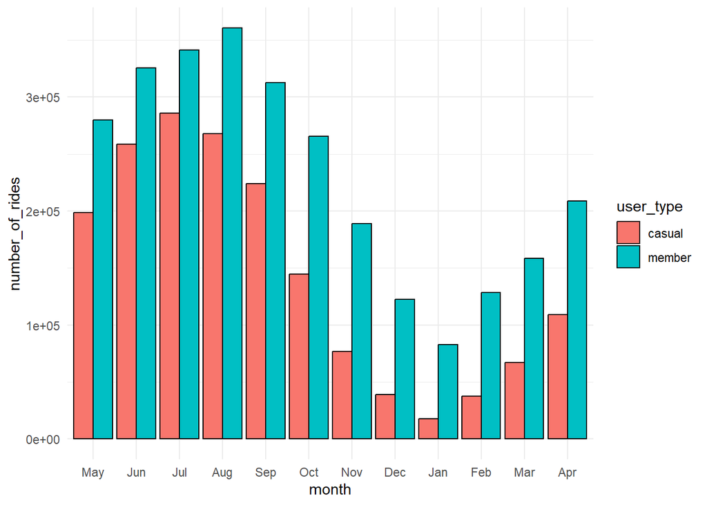

Plot number of rides per day by user type

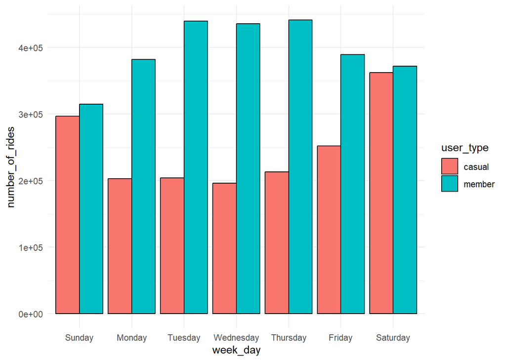

Plot number of rides by hour of day grouped by user_type

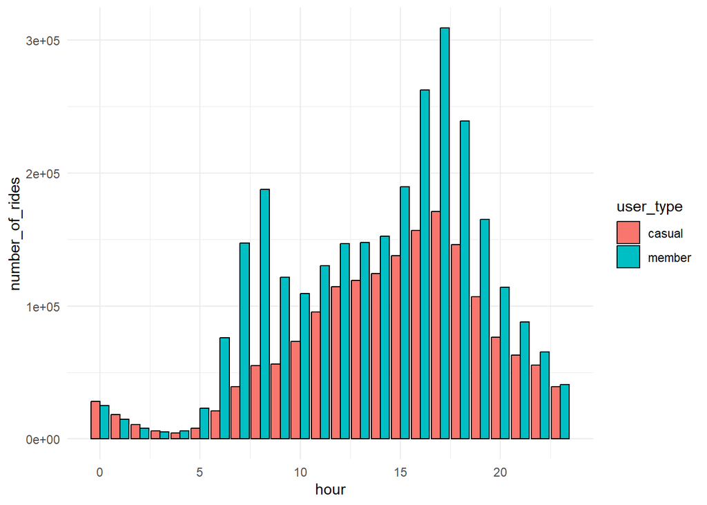

Plot number of rides by bike_type grouped by user_type

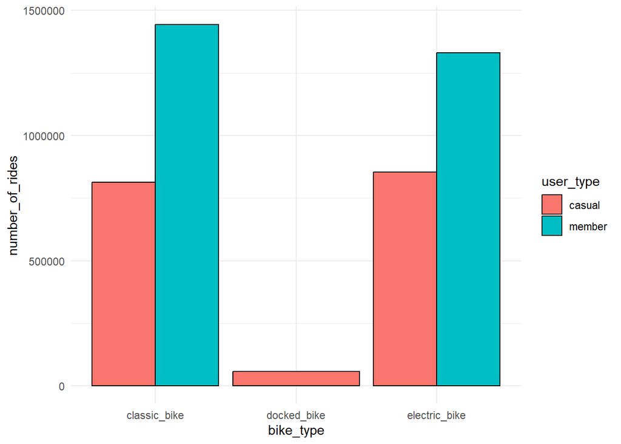

Save the final cleaned and tidy data to csv file

```r
write.csv(cleaned_df_selected, file = "data/cleaned_df_selected_final.csv",row.names = FALSE)
```

# Final report

### Restated business task

To design marketing strategies aimed at converting casual riders into annual members by better understanding how annual members and casual riders differ, why casual riders would buy a membership, and how digital media could affect their marketing tactics.

### Description of all data sources used

All data came from the publicly available rideshare data on the Divvy website. See above for specific data file names.

### Documentation of any cleaning or manipulation of data

Raw data files were concatenated into one large file with over 5.7 million rows of data, Rows with NA values, blank, duplicate and empty cells were deleted (i.e. only complete cases were retained). The time date columns (started_at, ended_at) were converted from character to date format and ride times less than 5 minutes or more than 1440 minutes (1 day) were deleted. This left just over 4.5 million rows of data. Dates were separated into individual components for easier analysis and converted from character to factor format. Finally a new data frame was made with only the columns needed for analysis. A csv file of each step was saved to the working directory.

### Supporting visualizations and key findings

See above in the data visualization section

- Provide promotions for specific tourist destinations on the lower usage days for members and casual users to get to tourist/shopping destinations.
- Offer hot chocolate or coffee at the busiest turn in destinations in the winter months
- Collect age and gender data to make more specific and targeted recommendations
- Passports can be issued with specific stamps given at various destinations and turn-in locations

### Final remarks

Sadly, during the preparation of this case study (June 2024), the local Houston, TX bicycle ride share program announced that it would be shutting down this summer.

# Appendix A

## Data License Agreement

Lyft Bikes and Scooters, LLC (“Bikeshare”) operates the City of Chicago’s (“City”) Divvy bicycle sharing service. Bikeshare and the City are committed to supporting bicycling as an alternative transportation option. As part of that commitment, the City permits Bikeshare to make certain Divvy system data owned by the City (“Data”) available to the public, subject to the terms and conditions of this License Agreement (“Agreement”). By accessing or using any of the Data, you agree to all of the terms and conditions of this Agreement.

License. Bikeshare hereby grants to you a non-exclusive, royalty-free, limited, perpetual license to access, reproduce, analyze, copy, modify, distribute in your product or service and use the Data for any lawful purpose (“License”). Prohibited Conduct. The License does not authorize you to do, and you will not do or assist others in doing, any of the following

Use the Data in any unlawful manner or for any unlawful purpose; Host, stream, publish, distribute, sublicense, or sell the Data as a stand-alone dataset; provided, however, you may include the Data as source material, as applicable, in analyses, reports, or studies published or distributed for non-commercial purposes; Access the Data by means other than the interface Bikeshare provides or authorizes for that purpose; Circumvent any access restrictions relating to the Data; Use data mining or other extraction methods in connection with Bikeshare’s website or the Data; Attempt to correlate the Data with names, addresses, or other information of customers or Members of Bikeshare; and State or imply that you are affiliated, approved, endorsed, or sponsored by Bikeshare. Use or authorize others to use, without the written permission of the applicable owners, the trademarks or trade names of Lyft Bikes and Scooters, LLC, the City of Chicago or any sponsor of the Divvy service. These marks include, but are not limited to DIVVY, and the DIVVY logo, which are owned by the City of Chicago. No Warranty. THE DATA IS PROVIDED “AS IS,” AS AVAILABLE (AT BIKESHARE’S SOLE DISCRETION) AND AT YOUR SOLE RISK. TO THE MAXIMUM EXTENT PROVIDED BY LAW BIKESHARE DISCLAIMS ALL WARRANTIES, EXPRESS OR IMPLIED, INCLUDING THE IMPLIED WARRANTIES OF MERCHANTABILITY FITNESS FOR A PARTICULAR PURPOSE, AND NON-INFRINGEMENT. BIKESHARE FURTHER DISCLAIMS ANY WARRANTY THAT THE DATA WILL MEET YOUR NEEDS OR WILL BE OR CONTINUE TO BE AVAILABLE, COMPLETE, ACCURATE, TIMELY, SECURE, OR ERROR FREE.

Limitation of Liability and Covenant Not to Sue. Bikeshare, its parent, affiliates and sponsors, and their respective directors, officers, employees, or agents will not be liable to you or anyone else for any loss or damage, including any direct, indirect, incidental, and consequential damages, whether foreseeable or not, based on any theory of liability, resulting in whole or in part from your access to or use of the Data. You will not bring any claim for damages against any of those persons or entities in any court or otherwise arising out of or relating to this Agreement, the Data, or your use of the Data. In any event, if you were to bring and prevail on such a claim, your maximum recovery is limited to $100 in the aggregate even if you or they had been advised of the possibility of liability exceeding that amount. Ownership and Provision of Data. The City of Chicago owns all right, title, and interest in the Data. Bikeshare may modify or cease providing any or all of the Data at any time, without notice, in its sole discretion. No Waiver. Nothing in this Agreement is or implies a waiver of any rights Bikeshare or the City of Chicago has in the Data or in any copyrights, patents, or trademarks owned or licensed by Bikeshare, its parent, affiliates or sponsors. The DIVVY trademarks are owned by the City of Chicago. Termination of Agreement. Bikeshare may terminate this Agreement at any time and for any reason in its sole discretion. Termination will be effective upon Bikeshare’s transmission of written notice to you at the email address you provided to Bikeshare in connection with this or by Bikeshare’s announcement on its website (currently www.divvybikes.com/data that it is revoking all licenses. Sections 2–6 and 9–10 will survive termination. Contact. Questions relating to this Agreement, including requests for permission to use trademarks and trade names, should be sent to bike-data@lyft.com. Applicable Law and Forum. This Agreement is governed by the laws of the State of Illinois, without regard to conflicts of law principles. Any dispute arising under or relating to this Agreement will be brought only in a court of competent jurisdiction sitting in New York City, New York. Entire Agreement. This Agreement is the complete and exclusive agreement and understanding between Bikeshare and you with respect to its subject matter and supersedes all prior or contemporaneous oral or written agreements or understandings relating to the subject matter.